# Mathan Brewer XML Vignette

Mathan Brewer

10/14/2019

#Background

XML stands for eXtensible Markup Language, and it is a markup language for structured data that was designed to store data and transfer data. It takes multiple peices on an observation and stores it in what is called a node. We can use multiple nodes to create a set of data. This allows the data to be stored in a simplier manner, so that it is more efficient in terms of reading, writing and querying. For this example we will be looking at SAT data from data.gov found at [this website](https://data.ct.gov/api/views/kbxi-4ia7/rows.xml?accessType=DOWNLOAD). This dataset contains information about differences in SAT score and individuals who took it from 2012 to 2013 in Connecicut.

#Data and Packages

##Read Into R

To begin reading thisTo begin reading this data into R we first need to install a package to deal with this type of data. I choose to use “XML” to read in this data into R. I used this package because it seemed to be the easiest to read in the data as a data frame using and it gives us the ability to parse or segmetns out the nodes look at one or more of the mrouped together. I used the xmlToDataFrame to read the data in. If we wanted to parse the data we could have used xml parse.

```r
install.packages("XML")
library(XML)
SAT<-xmlToDataFrame("rows.xml")
```

Below are the first ten observations of the data frame.

```r
head(SAT, n =10)
```

```
##    district_number   district                     school test_takers_2012
## 1            26111    Ansonia        Ansonia High School              118
## 2            46111       Avon           Avon High School              254
## 3            76111     Berlin         Berlin High School              216
## 4            96111     Bethel         Bethel High School              200
## 5           116111 Bloomfield     Bloomfield High School              116
## 6           116211 Bloomfield    Big Picture High School               14
## 7           126111     Bolton         Bolton High School               62
## 8           146111   Branford       Branford High School              196
## 9           156111 Bridgeport        Bassick High School              105
## 10          156211 Bridgeport Central Magnet High School              346
##    test_takers_2013 test_takers_change participation_rate_estimate_2012
## 1               104                -12                               67
## 2               243                 -4                               90
## 3               220                  2                               81
```

[output cut: 40 more lines]

For this data lets do a few things to it to make it easier for us to understand what is going on with these school. What I am going to do is create a variable that tells us if a school had met expected level of growth, so we are going to create a variable with levels based on percent meeting benchmark. We will have anything less than -2.5 to be “did not met growth”, between -2.5 and 2.5 as " met growth“, and finally anything greater that 2.5 will”exceeded growth".

```r
SAT<-mutate(SAT, level_of_growth =
ifelse(percent_meeting_benchmark_change < -2.5, "Did not met growth",
ifelse(percent_meeting_benchmark_change >= -2.5 & percent_meeting_benchmark_change <=2.5, "Met growth",
ifelse(percent_meeting_benchmark_change > 2.5, "Exceeded growth", 0))))
head(SAT, n = 10)
```

```
##    district_number   district                     school test_takers_2012
## 1            26111    Ansonia        Ansonia High School              118
## 2            46111       Avon           Avon High School              254
## 3            76111     Berlin         Berlin High School              216
## 4            96111     Bethel         Bethel High School              200
## 5           116111 Bloomfield     Bloomfield High School              116
## 6           116211 Bloomfield    Big Picture High School               14
## 7           126111     Bolton         Bolton High School               62
## 8           146111   Branford       Branford High School              196
## 9           156111 Bridgeport        Bassick High School              105
## 10          156211 Bridgeport Central Magnet High School              346
##    test_takers_2013 test_takers_change participation_rate_estimate_2012
## 1               104                -12                               67
## 2               243                 -4                               90
## 3               220                  2                               81
```

[output cut: 40 more lines]

We can now see this column in. Now meeting expected growth is great, but when your scores are already high it is going to be harder to continue growing, so let create a fuction to give a school a numeric score based on the value of the percent change and percent meeting in 2013.

```r
schoolgrade<- function(percent_meeting_2013, percent_meeting_change){
            newvalue<-percent_meeting_2013*.5+percent_meeting_change*.5
            return((newvalue/60)*100)
}
```

Now we can start to compare schools with different vaules for percent meeting and percent change. Look at the 1st observation and the 4th observation from the table about, if we go based just on their growth we may say that the 1st school is performing better, but lets us our new formula.

```r
schoolgrade(18,0)
```

```
## [1] 15
```

```r
schoolgrade(49,-2)
```

```
## [1] 39.16667
```

We can now compare these schools based on both variables, and we see a different story.

#Data Analysis

##Tables

We are first going to look at the number of school in each growth level to get a general idea where they are at.

```r
ftable(SAT$level_of_growth)
```

```
##  Did not met growth Exceeded growth Met growth
##
##                  46              66         77
```

It is good to see that many of the school have exceeded growth. Let’s look at this data again by district to start getting some more insight.

```r
table(SAT$district,SAT$level_of_growth)
```

```
##
##                                                      Did not met growth
##   Amistad Academy District                                            0
##   Ansonia                                                             0
##   Avon                                                                0
##   Berlin                                                              0
##   Bethel                                                              0
##   Bloomfield                                                          1
##   Bolton                                                              0
##   Branford                                                            1
##   Bridgeport                                                          0
##   Bristol                                                             2
##   Brookfield                                                          0
##   Canton                                                              1
##   Capitol Region Education Council                                    2
##   Cheshire                                                            0
##   Clinton                                                             1
##   Colchester                                                          1
##   Common Ground High                                                  0
##   Connecticut Technical High School System                            4
##   Coventry                                                            0
##   Cromwell                                                            1
##   Danbury                                                             0
##   Darien                                                              0
##   Derby                                                               1
##   East Granby                                                         1
##   East Haddam                                                         0
##   East Hampton                                                        0
##   East Hartford                                                       0
##   East Haven                                                          1
##   East Lyme                                                           0
##   East Windsor                                                        0
##   Eastern Connecticut Regional Educational Service C                  0
##   Ellington                                                           0
##   Enfield                                                             1
##   Explorations District                                               0
##   Fairfield                                                           0
##   Farmington                                                          0
##   Glastonbury                                                         0
##   Granby                                                              0
```

[output cut: 353 more lines]

```
##   Waterbury                                                   0
##   Waterford                                                   0
##   Watertown                                                   1
##   West Hartford                                               0
##   West Haven                                                  1
##   Westbrook                                                   1
##   Weston                                                      1
##   Westport                                                    0
##   Wethersfield                                                0
##   Wilton                                                      1
##   Windham                                                     0
##   Windsor                                                     1
##   Windsor Locks                                               0
##   Wolcott                                                     0
##   Woodstock Academy                                           0
```

[figure not shown]

```r
bigthree<-filter(SAT, SAT$district %in% c("Hartford", "New Haven", "Connecticut Technical High School System"))
levels <- ggplot(data = bigthree, aes(x = level_of_growth), na.rm = TRUE)
levels + geom_bar(aes( fill = as.factor(district)), na.rm = TRUE, position = "dodge") + xlab("Levels") +
  labs( fill = " ")
```

##Big Three

Since a lot of the school districts only have one or two school in them, we will take a look at the three largest Hartford, New Haven and Connecticut Technical High School System.

```r
bigthree<-filter(SAT, SAT$district %in% c("Hartford", "New Haven", "Connecticut Technical High School System"))
table(bigthree$district, bigthree$level_of_growth)
```

```
##
##                                            Did not met growth
##   Connecticut Technical High School System                  4
##   Hartford                                                  2
##   New Haven                                                 3
##
##                                            Exceeded growth Met growth
##   Connecticut Technical High School System               4          8
##   Hartford                                               6          5
##   New Haven                                              2          5
```

Well these three all seem at a glance, but New Haven and Hartford are not too far from each other so we are going to compare these three more to maybe get an idea of which of these maybe the best. The first thing we are going to look at is a scatterplot to see if maybe some of these schools are already at a higher level and are struggling to get muchh growth.

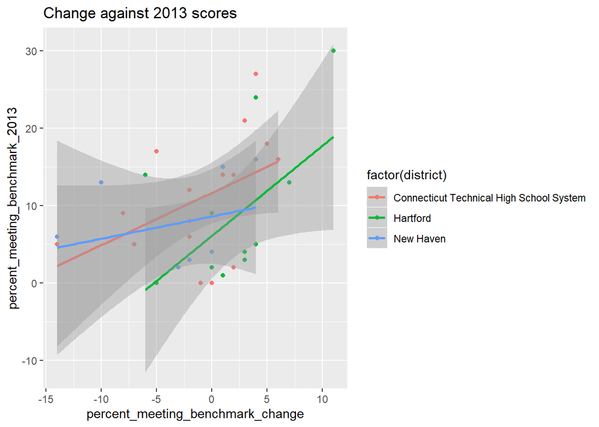

```r
changevs2013 <- ggplot(bigthree, aes(x= percent_meeting_benchmark_change, y = percent_meeting_benchmark_2013, colour = factor(district)))

changevs2013 + geom_point(aes(colour = factor(district)))+labs( title = "Change against 2013 scores")+geom_smooth(se = FALSE, method = lm)+geom_smooth(method = lm)
```

All of school have a positive slope, but it looks as if Hartford may have the best growth. Lets at a few other thinngs between these. We are going to dispay the percent change as box plots to get and idea of where they lie.

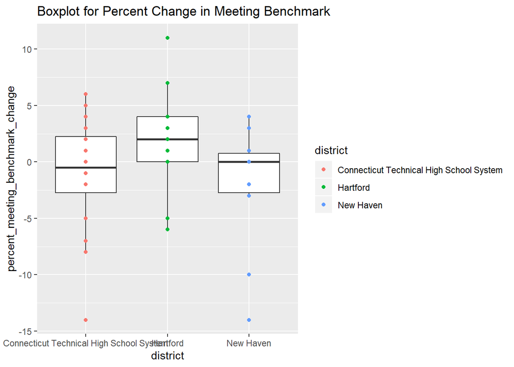

```r
changevalue <- ggplot(bigthree, aes(x = district, y = percent_meeting_benchmark_change))
changevalue + geom_boxplot() + geom_point(aes(colour = district))+labs( title = "Boxplot for Percent Change in Meeting Benchmark")
```

Again it looks like Hartford is ahead, but I am going to leave you with a few values, about the percent change in students meeting benchmarks, for you to dig further and decide for yourself which district you think it the best.

```r
summarize(group_by(bigthree, district), mean = mean(percent_meeting_benchmark_change, na.rm = TRUE), StdDev= sd(percent_meeting_benchmark_change, na.rm = TRUE))
```

```
## # A tibble: 3 x 3
##   district                                  mean StdDev
##   <chr>                                    <dbl>  <dbl>
## 1 Connecticut Technical High School System -1.12   5.30
## 2 Hartford                                  1.85   4.49
## 3 New Haven                                -2.1    5.69
```